# Linear Regression_homework

01_강효진

2018년 11월 10일

## 1. 데이터 살펴보기

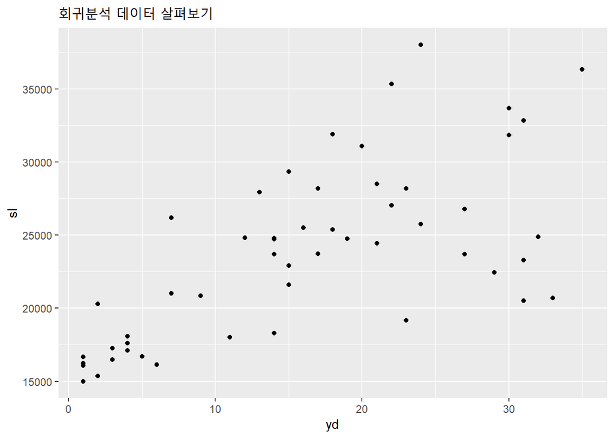

```r
library(readr)
library(dplyr)
library(ggplot2)
library(lmtest)

#데이터 불러오기
salary <- read_table2("http://data.princeton.edu/wws509/datasets/salary.dat")
View(salary)

#데이터 살펴보기
ggplot(salary, aes(x=yd, y=sl)) +
  geom_point() +
  labs(title="회귀분석 데이터 살펴보기")
```

- 변수설명
  - yd = Number of years since highest degree was earned (최고학위를 취득한 이후로 경과된 년수)
  - sl = Academic year salary, in dollars. (연봉, 달러기준)

## 2. 계수 추정

```r
#lm 함수
salaryLm <- lm(sl ~ yd, salary)
print(salaryLm)
```

```
##
## Call:
## lm(formula = sl ~ yd, data = salary)
##
## Coefficients:
## (Intercept)           yd
##     17502.3        390.6
```

```r
print(summary(salaryLm))
```

```
##
## Call:
## lm(formula = sl ~ yd, data = salary)
##
## Residuals:
##     Min      1Q  Median      3Q     Max
## -9703.5 -2319.5  -437.1  2631.8 11167.3
##
## Coefficients:
##             Estimate Std. Error t value Pr(>|t|)
## (Intercept) 17502.26    1149.70  15.223  < 2e-16 ***
## yd            390.65      60.41   6.466  4.1e-08 ***
## ---
## Signif. codes:  0 '***' 0.001 '**' 0.01 '*' 0.05 '.' 0.1 ' ' 1
##
## Residual standard error: 4410 on 50 degrees of freedom
## Multiple R-squared:  0.4554, Adjusted R-squared:  0.4445
## F-statistic: 41.82 on 1 and 50 DF,  p-value: 4.102e-08
```

```r
#coef 함수
coef(salaryLm)
```

```
## (Intercept)          yd
##  17502.2574    390.6451
```

- 계수 : 390.65

## 3. 신뢰구간

```r
confint(salaryLm)
```

```
##                  2.5 %     97.5 %
## (Intercept) 15193.0161 19811.4987
## yd            269.3063   511.9839
```

- 신뢰구간 : 269.3063 ~ 511.9839

## 4. 시각화

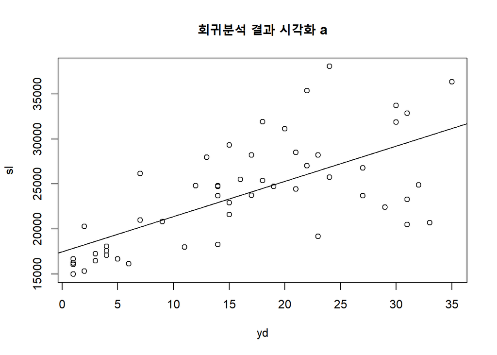

```r
#시각화a
plot(sl ~ yd, salary, main='회귀분석 결과 시각화 a'); abline(salaryLm)
```

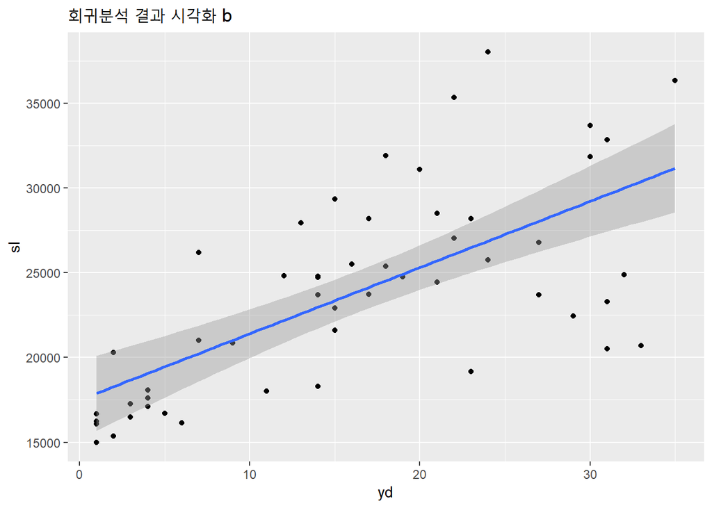

```r
#시각화b
ggplot(salary, aes(x=yd, y=sl)) +
  geom_point() +
  geom_smooth(method="lm") + labs(title='회귀분석 결과 시각화 b') #그룹별 회귀선 추가
```

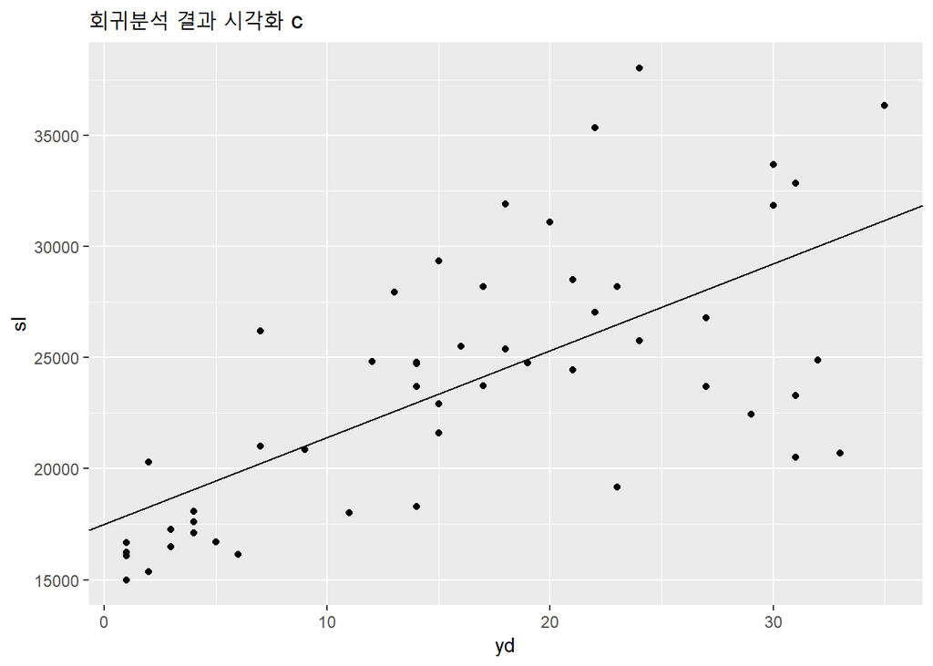

```r
#시각화c
ggplot(salary, aes(x=yd, y=sl)) +
  geom_point() +
  geom_abline(intercept = salaryLm$coefficients["(Intercept)"], #y절편
              slope = salaryLm$coefficients["yd"]) + #기울기
  labs(title='회귀분석 결과 시각화 c')
```

## 5. 진단

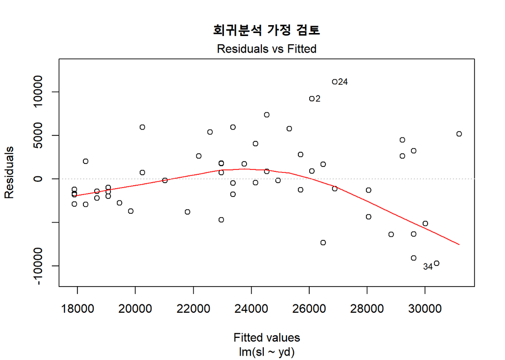

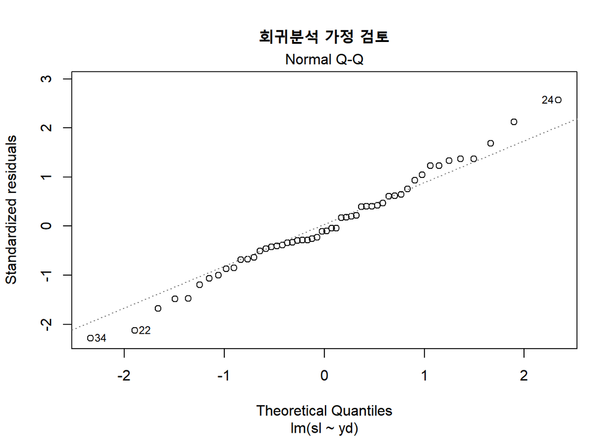

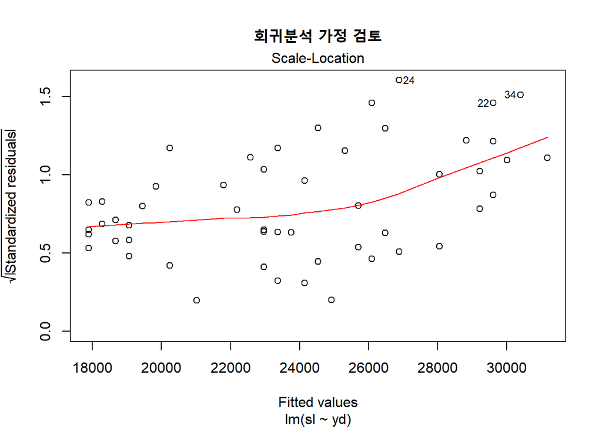

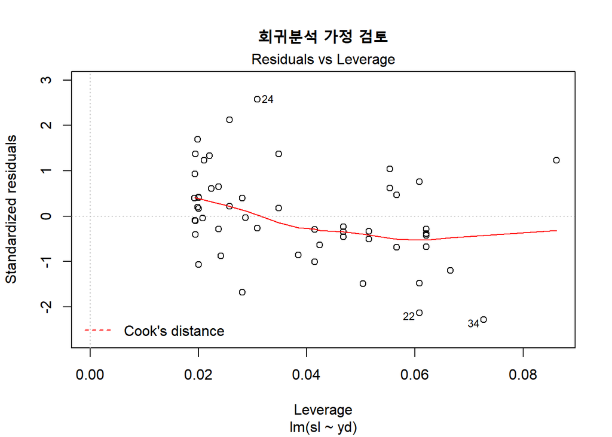

```r
plot(salaryLm, main='회귀분석 가정 검토')
```

- plot 분석
  - 1. x와 y의 관계가 선형적인가? 그래프 모양이 오른쪽에서 크게 기울어지는 것으로 보아, 완벽히 선형적이라고 할 수 없다.
  - 2. 잔차가 정규성을 띄는가? 왼쪽, 오른쪽 양끝의 경우 값이 기준선에서 벗어난 모습을 보이지만 전반적인 분포는 기준선에 가깝기 때문에 정규성을 만족하는 것으로 판단할 수 있다.
  - 3. 잔차가 등분산인가? 앞서 본 잔차의 분포와 마찬가지로 오른쪽으로 상승하는 모양의 그래프를 볼 수 있다. 따라서 등분산을 갖는다고 보기 어렵다.
  - 4. 특이값(계수 추정에 큰 영향을 미치는 값)이 존재하는가? 22번과 34번 관측치가 먼 거리에 있지만, 계수 추정에 큰 영향을 미치는 값은 없는 것으로 보인다.
- 분석 결과 종합 : 전반적으로 안정적인 모습을 보이고 있지만, 선형성을 만족하지 못하고 있다.